# Prak MPDW 5

#### Plot Boxcox

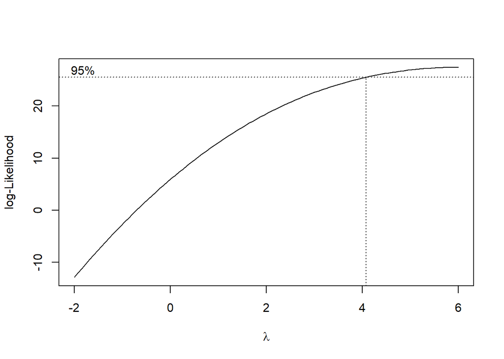

```r
index <- seq(1:67)
bc = boxcox(dt_stas1~index, lambda = seq(-2,6,by=1))
```

```r
#Nilai Rounded Lambda
lambda <- bc$x[which.max(bc$y)]
lambda
```

```
## [1] 6
```

```r
#SK
bc$x[bc$y > max(bc$y) - 1/2 * qchisq(.95,1)]
```

```
##  [1] 4.141414 4.222222 4.303030 4.383838 4.464646 4.545455 4.626263 4.707071
##  [9] 4.787879 4.868687 4.949495 5.030303 5.111111 5.191919 5.272727 5.353535
## [17] 5.434343 5.515152 5.595960 5.676768 5.757576 5.838384 5.919192 6.000000
```

#### Bagian 2

```r
dt_stas2 <- stas5[1:95] |> ts()
mean(dt_stas2)
```

```
## [1] 643562.2
```

```r
var(dt_stas2)
```

```
## [1] 8971108441
```

#### Plot Time Series

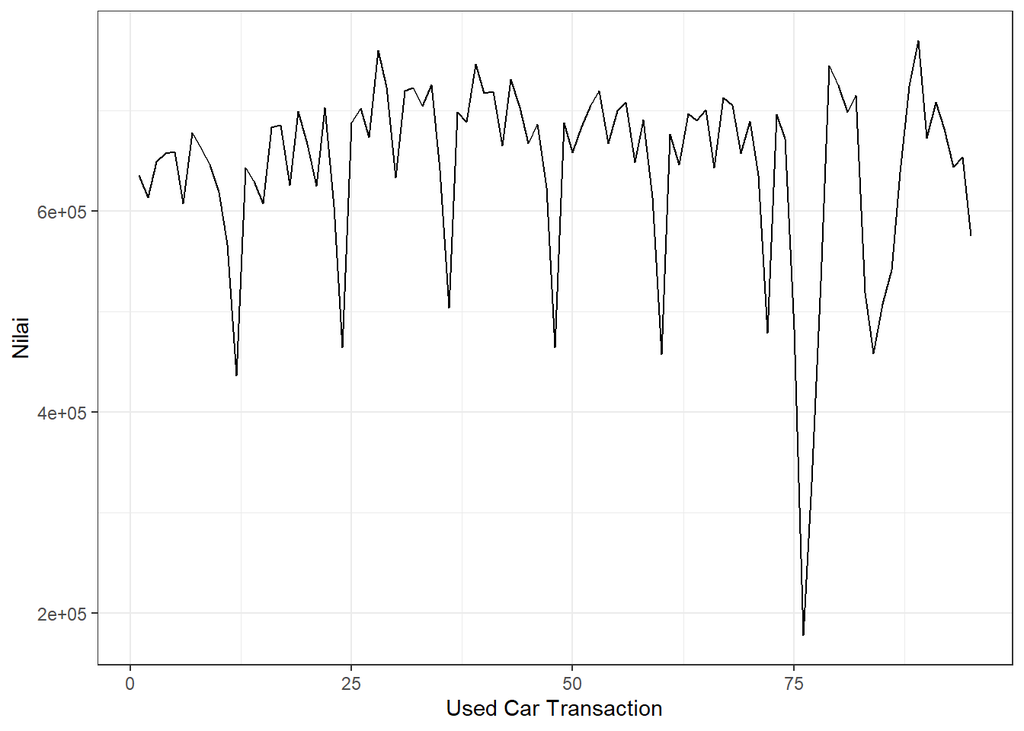

```r
dt_stas2 |> as_tsibble() |>
  ggplot(aes(x = index, y = value)) +
  geom_line() + theme_bw() +
  xlab("Used Car Transaction") + ylab("Nilai")
```

#### Plot ACF

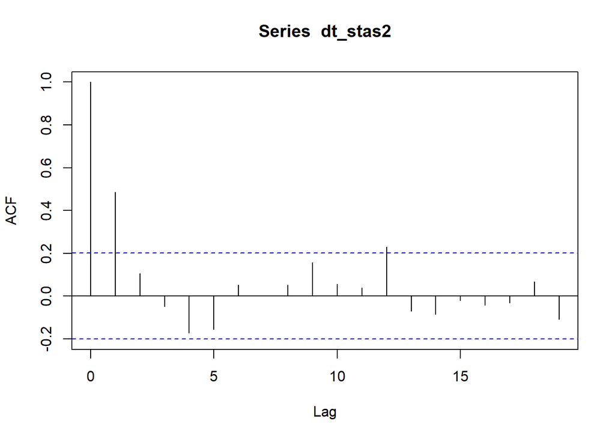

```r
acf(dt_stas2)
```

Berdasarkan plot ACF, terlihat bahwa plot ACF pada data tersebut cenderung *tails off* dan membentuk gelombang sinus.

#### Uji ADF

```r
adf.test(dt_stas2)
```

```
##
##  Augmented Dickey-Fuller Test
##
## data:  dt_stas2
## Dickey-Fuller = -4.5159, Lag order = 4, p-value = 0.01
## alternative hypothesis: stationary
```

$H_0$ : Data tidak stasioner dalam rataan

$H_1$ : Data stasioner dalam rataan

Berdasarkan uji ADF tersebut, didapat *p-value* sebesar 0.01 yang lebih kecil dari taraf nyata 5% sehingga tolak $H_0$ dan menandakan bahwa data stasioner dalam rataan. Hal ini sesuai dengan hasil eksplorasi menggunakan plot time series dan plot ACF.

#### Plot Boxcox

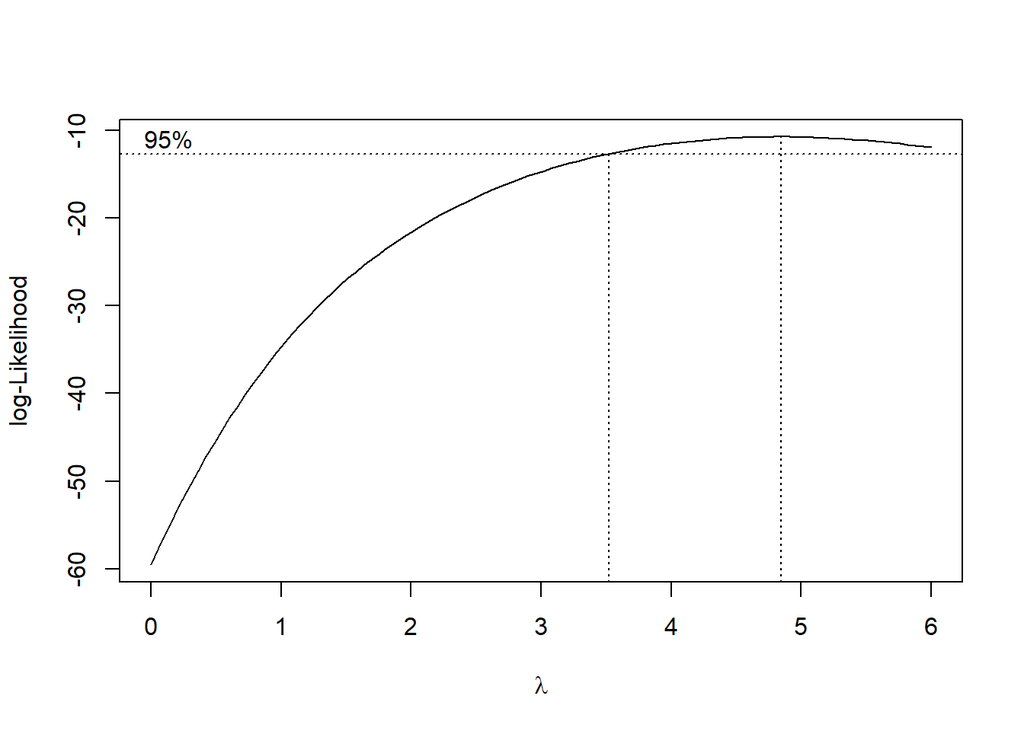

```r
index <- seq(1:95)
bc = boxcox(dt_stas2~index, lambda = seq(0,6,by=1))
```

```r
#Nilai Rounded Lambda
lambda <- bc$x[which.max(bc$y)]
lambda
```

```
## [1] 4.848485
```

```r
#SK
bc$x[bc$y > max(bc$y) - 1/2 * qchisq(.95,1)]
```

```
##  [1] 3.575758 3.636364 3.696970 3.757576 3.818182 3.878788 3.939394 4.000000
##  [9] 4.060606 4.121212 4.181818 4.242424 4.303030 4.363636 4.424242 4.484848
## [17] 4.545455 4.606061 4.666667 4.727273 4.787879 4.848485 4.909091 4.969697
## [25] 5.030303 5.090909 5.151515 5.212121 5.272727 5.333333 5.393939 5.454545
## [33] 5.515152 5.575758 5.636364 5.696970 5.757576 5.818182 5.878788 5.939394
## [41] 6.000000
```